# Stats 506, F18, Problem Set 1

Ruirui Zhang, ruiruiz@umich.edu

October 02, 2018

## Question 2:

### Question 2a:

Which airlines were responsible for at least 1% of the flights departing any of the three NYC airports between January 1 and October 31, 2013?

**Table 1.** *List of airlines responsible for at least 1% of the flights departing any of the three NYC airports between January 1 and October 31, 2013.* Rows are sorted by the airline code

| Airline Code | Full Name |
| --- | --- |
| 9E | Endeavor Air Inc. |
| AA | American Airlines Inc. |
| B6 | JetBlue Airways |
| DL | Delta Air Lines Inc. |
| EV | ExpressJet Airlines Inc. |
| FL | AirTran Airways Corporation |
| MQ | Envoy Air |
| UA | United Air Lines Inc. |
| US | US Airways Inc. |
| VX | Virgin America |
| WN | Southwest Airlines Co. |

### Question 2b:

Among the airlines from part “a”, compare the number and percent of annual flights in the first 10 months of 2013 and the first 10 months of 2014. Your table should include: the airline name (not carrier code), a nicely formatted number (see format()), percents for each year with 95% CI, and change in percent with 95% CI. Which airlines showed the largest increase and decrease? Why do some airlines show an increase in the percent of flights but a decrease in the number of flights?

**Delta Air Lines Inc.** showed the **largest increase** (2.18%).

**Endeavor Air Inc.** showed the **largest decrease** in the number of flights, which is 5.41% (No flights in 2014).

Because the total number of flights departured from NYC was decreased in 2014 (from 2013), some airlines show an increase in the percent of flights but a decrease in the number of flights, inclusing American Airlines Inc., JetBlue Airways, United Air Lines Inc., and US Airways Inc.

**Table 2.** *Comparison of the number and percent of annual flights in the first 10 months of 2013 and the first 10 months of 2014.* Each row shows one airline from part “a”. Rows are sorted by the airline name.

| Airline_Name | Number of Flights in 2013 | Percentage in 2013 | 95% CI for Percentage in 2013 (lower) | 95% CI for Percentage in 2013 (upper) | Number of Flights in 2014 | Percentage in 2014 | 95% CI for Percentage in 2014 (lower) | 95% CI for Percentage in 2014 (upper) | Change in Percentage (from 2013 to 2014) | 95% CI for Change in Percentage in 2014 (lower) | 95% CI for Change in Percentage in 2014 (upper) |
| --- | --- | --- | --- | --- | --- | --- | --- | --- | --- | --- | --- |
| AirTran Airways Corporation | 2845 | 1.011 | 0.974 | 1.048 | 1251 | 0.494 | 0.467 | 0.521 | -0.517 | -0.563 | -0.471 |
| American Airlines Inc. | 27447 | 9.755 | 9.645 | 9.864 | 26302 | 10.383 | 10.264 | 10.502 | 0.628 | 0.467 | 0.790 |
| Delta Air Lines Inc. | 40168 | 14.276 | 14.146 | 14.405 | 41683 | 16.455 | 16.311 | 16.599 | 2.179 | 1.985 | 2.373 |
| Endeavor Air Inc. | 15232 | 5.413 | 5.330 | 5.497 | NA | NA | NA | NA | NA | NA | NA |
| Envoy Air | 22202 | 7.891 | 7.791 | 7.990 | 18559 | 7.326 | 7.225 | 7.428 | -0.564 | -0.706 | -0.422 |
| ExpressJet Airlines Inc. | 45395 | 16.133 | 15.997 | 16.269 | 39819 | 15.719 | 15.577 | 15.861 | -0.414 | -0.611 | -0.218 |
| JetBlue Airways | 45605 | 16.208 | 16.072 | 16.344 | 44479 | 17.559 | 17.411 | 17.707 | 1.351 | 1.149 | 1.552 |
| Southwest Airlines Co. | 10143 | 3.605 | 3.536 | 3.674 | 11902 | 4.698 | 4.616 | 4.781 | 1.094 | 0.986 | 1.201 |
| United Air Lines Inc. | 48880 | 17.372 | 17.232 | 17.512 | 46267 | 18.265 | 18.114 | 18.415 | 0.893 | 0.687 | 1.098 |
| US Airways Inc. | 17232 | 6.124 | 6.036 | 6.213 | 16750 | 6.612 | 6.516 | 6.709 | 0.488 | 0.357 | 0.619 |
| Virgin America | 4235 | 1.505 | 1.460 | 1.550 | 4797 | 1.894 | 1.841 | 1.947 | 0.389 | 0.319 | 0.458 |

### Question 2c:

Among of the three NYC airports, produce a table showing the percent of flights each airline is responsible for. Limit the table to the airlines identified in part a and include confidence intervals for your estimates. Which airline is the largest carrier at each airport?

Tables below show percent of flights in each of three NYC airport each airline is responsible for, based on data from **Jan.1 to Oct. 31 2014**. We have included **airlines selected in part “a”** only, except Endeavor Air Inc.. This is becasue there is **no flights carried by Endeavor Air Inc. in 2014** according to data.

Largest carrier at **JFK**: JetBlue Airways

Largest carrier at **EWR**: United Air Lines Inc.

Largest carrier at **LGA**: Delta Air Lines Inc.

|  | Percent of flight from JFK | 95% CI for percentage (upper) | 95% CI for percentage (lower) |
| --- | --- | --- | --- |
| American Airlines Inc. | 4.707 | 4.625 | 4.789 |
| JetBlue Airways | 13.509 | 13.376 | 13.641 |
| Delta Air Lines Inc. | 7.445 | 7.344 | 7.547 |
| ExpressJet Airlines Inc. | 0.422 | 0.397 | 0.447 |
| AirTran Airways Corporation | 0.000 | 0.000 | 0.000 |
| Envoy Air | 2.149 | 2.093 | 2.205 |
| United Air Lines Inc. | 1.549 | 1.501 | 1.597 |
| US Airways Inc. | 1.044 | 1.005 | 1.084 |
| Virgin America | 1.239 | 1.196 | 1.282 |
| Southwest Airlines Co. | 0.000 | 0.000 | 0.000 |

|  | Percent of flight form EWR | 95% CI for percentage (upper) | 95% CI for percentage (lower) |
| --- | --- | --- | --- |
| American Airlines Inc. | 1.046 | 1.006 | 1.085 |
| JetBlue Airways | 2.161 | 2.104 | 2.217 |
| Delta Air Lines Inc. | 1.639 | 1.590 | 1.689 |
| ExpressJet Airlines Inc. | 11.183 | 11.061 | 11.305 |
| AirTran Airways Corporation | 0.000 | 0.000 | 0.000 |
| Envoy Air | 0.066 | 0.056 | 0.076 |
| United Air Lines Inc. | 14.260 | 14.125 | 14.396 |
| US Airways Inc. | 1.374 | 1.329 | 1.419 |
| Virgin America | 0.649 | 0.618 | 0.680 |
| Southwest Airlines Co. | 1.898 | 1.845 | 1.950 |

|  | Percent of flight form LGA | 95% CI for percentage (upper) | 95% CI for percentage (lower) |
| --- | --- | --- | --- |
| American Airlines Inc. | 4.631 | 4.549 | 4.712 |
| JetBlue Airways | 1.889 | 1.837 | 1.942 |
| Delta Air Lines Inc. | 7.370 | 7.269 | 7.471 |
| ExpressJet Airlines Inc. | 4.114 | 4.037 | 4.191 |
| AirTran Airways Corporation | 0.494 | 0.467 | 0.521 |
| Envoy Air | 5.111 | 5.026 | 5.197 |
| United Air Lines Inc. | 2.455 | 2.395 | 2.515 |
| US Airways Inc. | 4.194 | 4.117 | 4.272 |
| Virgin America | 0.006 | 0.003 | 0.009 |
| Southwest Airlines Co. | 2.801 | 2.737 | 2.865 |

### Question 3a:

What percent of homes have stucco construction as the major outside wall material within each division? Which division has the highest proportion? Which the lowest?

**Table 4** *Summary of the percent of homes have stucco construction as the major outside wall material within each division.* Each row shows a different division.

|  | Percent of homes | 95 CI (Lower) | 95 CI (Upeer) |
| --- | --- | --- | --- |
| New England | 1.227 | -0.343 | 2.797 |
| Middle Atlantic | 2.062 | 0.622 | 3.501 |
| East North Central | 0.657 | 0.101 | 1.212 |
| West North Central | 4.866 | 0.891 | 8.840 |
| South Atlantic | 10.620 | 7.835 | 13.405 |
| East South Central | 0.423 | -0.379 | 1.225 |
| West South Central | 2.987 | 1.627 | 4.348 |
| Mountain North | 16.606 | 10.249 | 22.962 |
| Mountain South | 64.248 | 55.447 | 73.049 |
| Pacific | 44.586 | 41.279 | 47.893 |

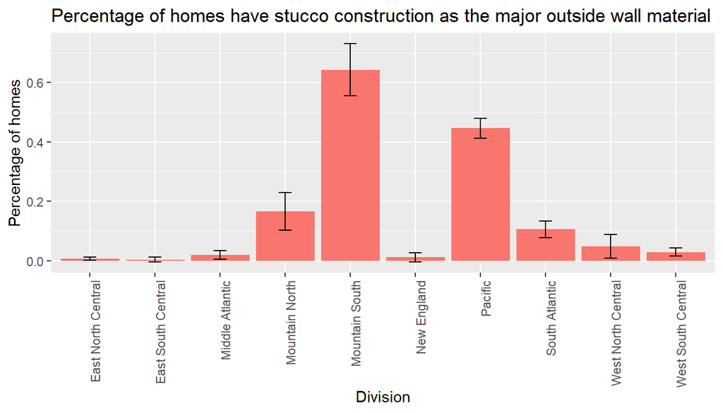

*Plot.a1* This plot shows the percent of homes have stucco construction as the major outside wall material.

### Question 3b:

What is average total electricity usage in kilowatt hours in each division? Answer the same question stratified by urban and rural status.

**Table 5.1** *Summary of average total electricity usage in kilowatt hours in each division.* Each row shows a different division.

|  | Average total electricity usage (all) | 95% CI (Lower) | 95% CI (Upeer) |
| --- | --- | --- | --- |
| New England | 7514.561 | 6471.809 | 8557.314 |
| Middle Atlantic | 8465.442 | 8071.295 | 8859.588 |
| East North Central | 9128.663 | 8729.556 | 9527.770 |
| West North Central | 10523.828 | 9634.725 | 11412.931 |
| South Atlantic | 13446.621 | 12903.930 | 13989.312 |
| East South Central | 14535.969 | 13319.533 | 15752.406 |
| West South Central | 14324.259 | 13495.096 | 15153.422 |
| Mountain North | 8384.471 | 7121.390 | 9647.552 |
| Mountain South | 10442.017 | 7950.081 | 12933.954 |
| Pacific | 8100.405 | 7750.355 | 8450.456 |

**Table 5.2** *Summary of average total electricity usage in kilowatt hours in each division, for rural status only.* Each row shows a different division.

|  | Average total electricity usage (rural) | 95% CI (Lower) | 95% CI (Upeer) |
| --- | --- | --- | --- |
| New England | 9001.054 | 6766.035 | 11236.07 |
| Middle Atlantic | 12223.389 | 10632.953 | 13813.82 |
| East North Central | 13500.024 | 12021.663 | 14978.39 |
| West North Central | 14173.932 | 12608.216 | 15739.65 |
| South Atlantic | 15941.991 | 14838.597 | 17045.38 |
| East South Central | 16332.679 | 14087.481 | 18577.88 |
| West South Central | 16317.160 | 14067.068 | 18567.25 |
| Mountain North | 9356.001 | 5698.085 | 13013.92 |
| Mountain South | 8610.426 | 6536.184 | 10684.67 |
| Pacific | 14114.760 | 12000.889 | 16228.63 |

**Table 5.3** *Summary of average total electricity usage in kilowatt hours in each division, for urban status only.* Each row shows a different division.

|  | Average total electricity usage (urban) | 95% CI (Lower) | 95% CI (Upeer) |
| --- | --- | --- | --- |
| New England | 7626.553 | 6549.371 | 8703.734 |
| Middle Atlantic | 7788.251 | 7367.321 | 8209.181 |
| East North Central | 7775.891 | 7276.811 | 8274.972 |
| West North Central | 9320.237 | 8261.268 | 10379.205 |
| South Atlantic | 12825.487 | 12117.074 | 13533.900 |
| East South Central | 14168.218 | 12132.269 | 16204.166 |
| West South Central | 14061.286 | 13160.650 | 14961.923 |
| Mountain North | 8143.720 | 7435.310 | 8852.131 |
| Mountain South | 10670.228 | 8112.333 | 13228.123 |
| Pacific | 7049.627 | 6433.484 | 7665.769 |

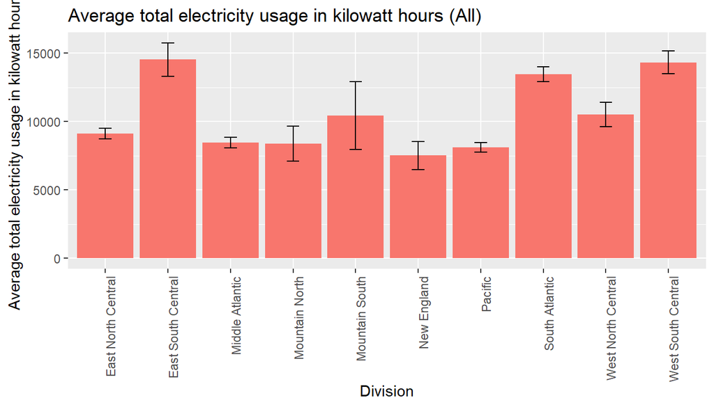

*Plot.b1* This plot shows the average total electricity usage in kilowatt hours by division, for all status.

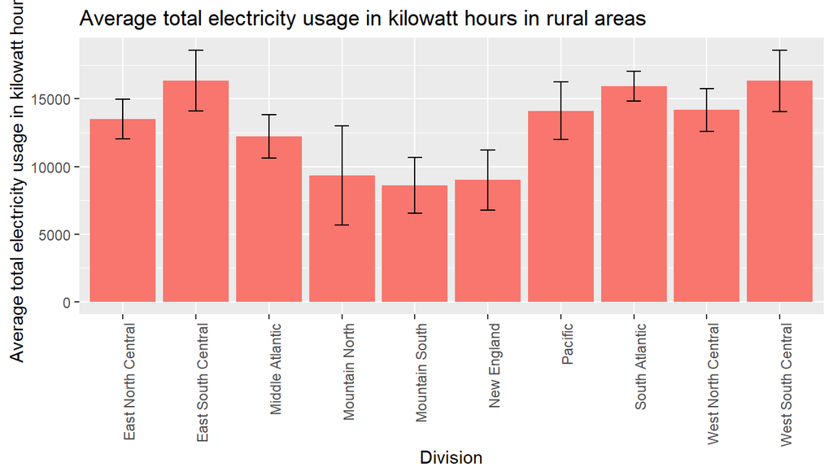

*Plot.b2* This plot shows the average total electricity usage in kilowatt hours by division, for rural status.

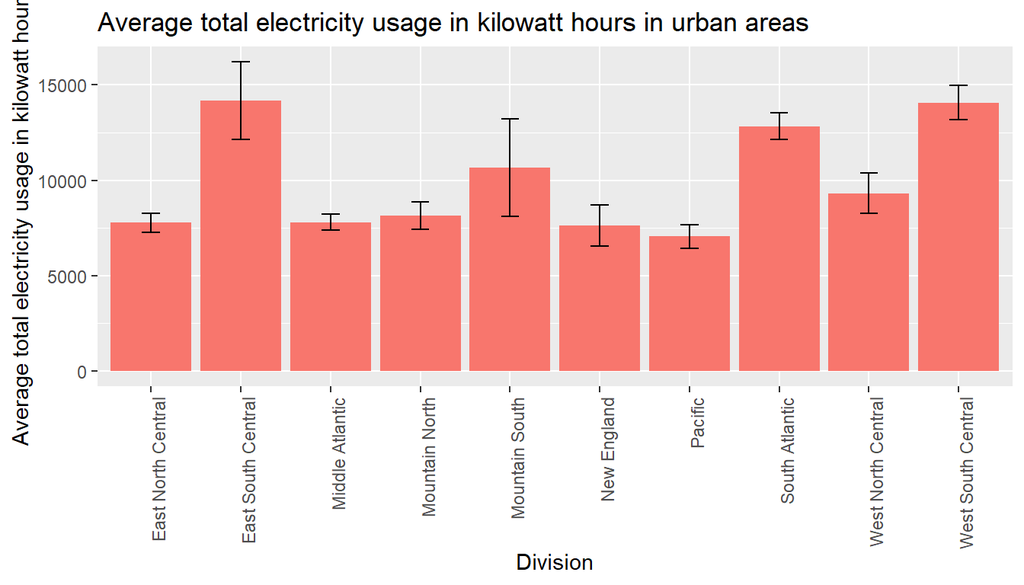

*Plot.b3* This plot shows the average total electricity usage in kilowatt hours by division, for urban status.

### Question 3c:

Which division has the largest disparity between urban and rural areas in terms of the proportion of homes with internet access?

**West Sourth Central** is the division has the largest disparity between urban and rural areas in terms of the proportion of homes with internet access.

**Table 3c** *Summary of the difference between urban and rural areas in terms of proportion of homes with internet access.* Each row shows a different division.

|  | Difference in proportion (rural and urban) | 95% CI (Lower) | 95% CI (Upeer) |
| --- | --- | --- | --- |
| New England | 10.499 | 8.711 | 12.287 |
| Middle Atlantic | 4.647 | 3.185 | 6.109 |
| East North Central | 1.616 | 0.179 | 3.054 |
| West North Central | 2.430 | 0.345 | 4.516 |
| South Atlantic | 8.815 | 6.951 | 10.680 |
| East South Central | 1.546 | -0.801 | 3.893 |
| West South Central | 10.781 | 8.606 | 12.957 |
| Mountain North | 7.478 | 5.116 | 9.840 |
| Mountain South | 1.826 | 0.828 | 2.824 |
| Pacific | 2.557 | 2.187 | 2.928 |

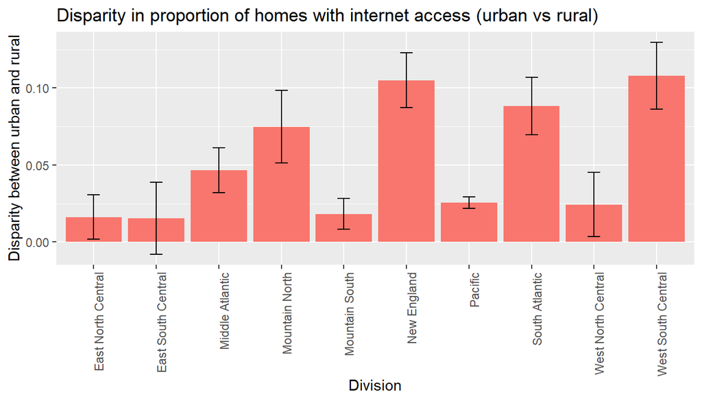

*Plot.c1* Difference between urban and rural areas in terms of the proportion of homes with internet access.